# Psychologia pracy i organizacji

Agata Zywert

17 marca 2018

## 1. Definicja pracy

- Działalność celowa, skierowana na przekształcania dóbr przyrody i przystosowanie ich do zaspokajania potrzeb jednostki (Wołk, 2000)
- Aktywność ukierunkowana na osiągnięcie cenionych celów, wykraczających poza przyjemność płynąca z samej aktywności (Warr, 2001)

> “Znaczenie pracy możemy zdefiniować na różne sposoby m.in. jako: działalności gospodarczą zmierzającą do zaspokojenia potrzeń, sposób wydatkowania siły roboczej, fizycznej i psychicznej, działanie zmierzające do pokonania oporu materii, czynność kształtująca przyrodę, formę uzewnętrzniania możliwości twórczych człowieka, sposób tworzenia kultury, podstawę kultury”

## 2. ILO

#### *Międzynarodowa Organizacja Pracy - International Labour Organization*

Została utworzona 28.06.1919, nie wiem w ogóle po co jest ta informacja o niej, ale na tym slajdzie jest również napisane o ustawach o zawodach, związkach zawodowych i stowarzyszeniach :)

## 3. Stosunek wobec pracy i postawy wobec pracy

- Stosunek do pracy jest to określenie złożone i obejmuje nie tylko wszelkie dziedziny pracy ludzkiej ale również sposób myślenia pracownika, jego życie duchowe, moralność i świadomość społeczną konkretnych grup pracowniczych
- Stosunek do pracy kształtuje się w poszczególnych zbiorowościach pod wpływem między innymi przemian społeczno - gospodarczych.
- Złożony i długotrwały proces kształtowania stosunku do pracy polega na zmianie psychiki człowieka i świadomości grupy, zmianie ich postaw wartości i dążeń.

## 4. Co wpływa na stosunek ludzi do pracy?

#### 3 grupy czynników

##### **czynniki ogólnie tak zwane *makrospołeczne*:**

- system społeczno – ekonomiczny
- ustrój społeczno polityczny, z systemem podejmowania decyzji politycznych, kulturowych

##### **Czynniki związane z indywidualnymi, zawodowymi, demograficznymi i osobowościowymi cechami pracownika:**

- płeć
- wiek
- stan rodziny
- wykształcenie itp.

##### **Czynniki związane z określonym rodzajem działalności ludzkiej, tzw. *mikrospołeczne* np.:**

- działalności produkcyjnej
- politycznej
- zawodowej

#### Obiektywny charakter stosunku do pracy wyraża się w takich postawach pracownika jak:

- efektywność pracy
- podejmowanie inicjatyw zawodowych
- podejmowanie działalności wynalazczej
- dyscyplinie pracy
- stosunkach międzyludzkich w zespołach pracowniczych i integracji z zakładem
- motywacji pracy
- chęci podnoszenia własnych kwalifikacji zawodowych

## 5. Zadowolenie z pracy

- Zadowolenie z pracy jako kategoria psycho – socjologiczna jest wypadkowa wielu czynników materialnych i pozamaterialnych.
- Z pojęciem tym łączy się stan równowagi pomiędzy potrzebami a oczekiwaniami pracownika wobec pracy, a ich zaspokojeniem.
- Zadowolenie z pracy jest wykładnikiem i jednocześnie wyznacznikiem określonych postaw wobec pracy, zawodu, zakładu.
- Nie jest ono wyłącznie funkcją tego, co praca daje, lecz tego, czego się jeszcze pragnie.
- Jest to wypadkowa satysfakcji z tego, co się ma i niezadowolenia z tego, czego się jeszcze nie ma.

## 6. Psychologia pracy

> “Psychologia pracy stawia sobie za cel badanie i rozwiązywanie zagadnień praktycznych związanych z pracą i działalnością zawodowa człowieka”

**Badania i zastosowanie psychologii pracy obejmują:**

- wzajemne przystosowanie człowieka i środowiska pracy
- stosunki społeczne w środowisku pracy
- motywację do pracy
- problemy kliniczne nieprzystosowania do pracy

## 7. Paradygmat pracy

- **Określony typ pracy badany przez psychologię tworzy dany dział psychologii pracy (PP) (np. psychologia transportu)**
- **Mimo zróżnicowania rodzajów prac i aktywności zawodowych człowieka zatem w PP można wskazać na wspólne i niemal zawsze te same problemy:**
- Wydajność
- Produktywność
- Jakość
- Bezpieczeństwo
- Przystosowanie
- Dopasowanie

## 7. Psychologia pracy // Psychologia przemysłowa

- **Psychologia pracy** – *work psychology* - Zajmuje się rożnego rodzaju pracami zawodowymi
- **Psychologia przemysłowa** – *industrial psychology* - Koncentruje się na pracy przemysłowej

## 8. Pytania w psychologii pracy

- Fizyczne warunki wykonywania pracy
- Metody wykonywania pracy
- Organizacja pracy
- Badanie uwarunkowań i przebiegu aktywności zawodowej człowieka
- Jakich zdolności wymaga wykonywanie różnego rodzaju prac
- Jakie prace preferują ludzie z różnym poziomem wykształcenia
- Skuteczność pracy –efekty
- Środowisko pracy
- Problematyka zatrudnienia w cyklu życia
- Zarządzanie kadrami
- Społeczne i polityczne aspekty funkcjonowania organizacji

## 9. Psychologia pracy –pytanie o to jak osiągnąć np.:

- **Skuteczność działania** – najwyższa ilość i jakość działania
- **Ekonomiczne parametry działania** – wysokie wyniki przy jak najmniejszym wysiłku i kosztach, najłatwiejszym sposobem i w jak najkrótszym czasie
- **Bezpieczeństwo człowieka** – skuteczne i ekonomicznie najlepsze parametry działania z minimalnymi ujemnymi skutkami ubocznymi
- **Zadowolenie z pracy oraz poczucie jej wysokiej jakości**

## 10. Psychologia człowieka pracującego

Psychologia poradnictwa i doradztwa zawodowego –zainteresowania zawodowe, preorientacja zawodowa, planowanie kariery zawodowej * **Psychologia zatrudnienia** – rozwój zawodowy pracownika, zawodoznawstwo * **Psychologia szkolenia zawodowego** – projektowanie i usprawnianie metod oraz organizacja szkoleń * **Psychologia kadr** – selekcja, klasyfikacja, ocena pracowników * **Psychologia organizacji i zarządzania** – motywacja do pracy, postawy pracowników, dynamika grupy, obieg informacji, metody zarządzania, rozwój organizacji

## 11. Praca jako kategoria poznawcza

**Praca w swoim interdyscyplinarnym charakterze wyraża:**

- Swoista formę stosunku człowieka do przyrody.
- Więzi między jednostkami ludzkimi.
- Stosunki społeczne.

## 12. Relacje człowiek - środowisko pracy

Środowisko to względnie trwały układ elementów otoczenia człowieka ważnych dla jego życia i zachowania się.

> “Fakt, że człowiek żyje i działa w określonym środowisku ma równie podstawowe znaczenie dla psychologii jako nauki o zachowaniu człowieka, jak i dla psychologii pracy, jako nauki o zachowaniu się człowieka w środowisku pracy” (Tomaszewski, 1975)

## 13. Układ człowiek - środowisko pracy

- Elementami środowiska człowieka są rzeczy i ludzie pozostający ze sobą w różnorodnych stosunkach, przy czym każdy człowiek jest też elementem swojego środowiska i to elementem wyróżnionym.
- Środowisko człowieka można rozpatrywać trojako: jako źródło stymulacji jego aktywności, jako zbiór czynników ukierunkowujących jego zachowanie (np. pracę) oraz jako podstawę organizacji jego zachowania się.
- Środowisko można rozpatrywać jako układ bodźców fizycznych, układ stosunków społecznych (więzi społecznych) oraz jako układ bodźców motywujących do działania.
- Życie i działalność człowieka mogą przebiegać tylko w przypadku istnienia w otoczeniu określonych elementów, a także określonych stanów i związków.
- W środowisku człowieka musi być odpowiednia temperatura, ciśnienie, światło, pożywienie, obecność innych ludzi itp. Związki te są szczególnie wyraźne w środowisku pracy i często się o nich mówi jako o warunkach wykonywania zadań pracy.

## 14. Człowiek w sytuacji pracy

**Regulatory i modyfikatory ludzkich zachowań mające wpływ na nasza pracę:**

- Cechy osobowości
- Temperament
- Emocje i czynniki motywacyjne
- Poczucie własnej skuteczności
- Wewnątrz i zewnątrz sterowność
- Twórczość

## 15. Motywacja do pracy:

> “Motywacja – proces regulacji, który steruje czynnościami człowieka tak, aby doprowadziły one do określonego efektu, takiego jak : zmiana w fizycznym lub społecznym stanie rzeczy” (Reykowski)
- **2 podstawowe aspekty procesu motywacyjnego**:
- **Kierunek** – wyznaczany przez wskazanie celu, do którego zmierza czynność
- **Siła dążeń** – stopień, w jakim dane dążenie kontroluje zachowanie

*Opisując procesy motywacyjne należy także uwzględnić towarzyszące im stany emocjonalne – **dodatnie** (radość, satysfakcja) i **ujemne** (żal, frustracja)*

## 16. Psychologia różnic indywidualnych w psychologii pracy:

#### Inteligencja:

- **Inteligencja** – zdolność do postrzegania, analizy i adaptacji do zmian otoczenia. Zdolność rozumienia, uczenia się oraz wykorzystywania posiadanej wiedzy i umiejętności w różnych sytuacjach
- **Inteligencja** to konstrukt teoretyczny odnoszący się do względnie stałych warunków wewnętrznychczłowieka, determinujących efektywność działań, wymagającychprocesów poznawczych. Warunki te kształtują się w wyniku interakcjigenotypu,środowiskai własnej aktywności człowieka. (Strelau)
- **Inteligencja** to ogólna zdolnośćadaptacjido nowych warunków i wykonywania nowych zadań przez wykorzystanie środków myślenia. (Stern)
- **Inteligencja** to właściwośćpsychiczna, która przejawia się we względnie stałej, charakterystycznej dla jednostki efektywności wykonywania zadań (Tiepłow)
- **Inteligencja** to zdolność rozwiązywania problemów (Piaget)
- **Inteligencja** to dostrzeganie zależności (edukcja relacji), relacji i wyciągania wniosków (edukcja korelacji). (Spearman)

`Po tym następuję jeszcze wiele innych definicji, które mówią to samo a to wszystko i tak było u dr Błażek`

#### Osobowość:

- Osobowość jako źródło różnic indywidualnych – ludzie różnią się między sobą ze względu na konstrukcję psychiczną
- Osobowość jako organizacja cech, dyspozycji –warunkujących stałość, powtarzalność zachowania się jednostki
- Osobowość rozpatrywana jako działanie sił psychodynamicznych
- Osobowość – a sprawność zawodowa człowieka, jego możliwości i ograniczenia
- Osobowość jest istotnym czynnikiem powodzenia w pracy czy efektywności zawodowej
- Osobowość wpływa na kształtowanie preferencji zawodowych
- Osobowość wpływa na percepcję pracy w kategoriach jej stresogenności
- obejmuje: potrzeby, postawy, temperament, zdolności i uzdolnienia, obraz siebie, samoocenę, zainteresowania

#### Temperament jako regulator zachowania:

- **Temperament** –z espół dziedziczonych cech osobowości, zdeterminowanych genetycznie i ujawniających się już w pierwszym roku życia człowieka. Tak rozumiany temperament stanowi podstawę kształtowania się i rozwoju osobowości
- Temperament to ważny czynnik regulacji zachowania i zdolności przystosowawczych jednostki
- Konstelacja cech temperamentu, która decyduje o efektywności pracownika (decyzyjność, aktywność zawodowa)
- Regulacyjny udział cech osobowości i temperamentu znaczący jest przy wykonywaniu zawodów trudnych i niebezpiecznych

## 17. Cechy człowieka a wykonywanie pracy

- **Człowiek jako podmiot pracy** – wgląd w mechanizmy regulujące jego stosunki z otoczeniem.
- Pojęcie *przydatności do pracy* – podstawa tworzenia koncepcji przyjmowania do pracy, diagnozy psychologicznej prowadzącej do orzekania o możliwościach człowieka i jego potencjalnych sukcesach i niepowodzeniach.
- To jak człowiek pracuje, jakie osiąga wyniki i jakie nadaje im znaczenie zależy od tego, jakie są jego **wartości** (czego pragnie, do czego dąży) oraz jego **możliwości.**

## 18. Pojęcie *„możliwości człowieka”*:

- W najszerszym rozumieniu możliwości to zdolność do spełniania wymagań, bardzo zbliżona do niezawodności (Ratajczak 1988).
- We współczesnych podejściach do analizy możliwości używa się pojęcia *zasobów* (Hobfoll, 1988), w teorii zarządzania mówi się o zasobach ludzkich, mając na myśli **rodzaj zintegrowanej siły tkwiącej w poszczególnych jednostkach wchodzących w skład personelu danej organizacji.**
- Na poziomie rozważań jednostkowych mówi się o potencjałach osoby, jej szczególnych cechach, talentach, unikatowych właściwościach, charyzmie, mocy sprawczej itp.
- Aktywność człowieka w toku wykonywania zadań bardzo wyraźnie zależy od jego konstytucji fizycznej, od zdrowia i sił, jakimi dysponuje. Takie możliwości mają ścisły związek z wydajnością pracy, przy wykonywaniu dużej liczby czynności._

## 19. Możliwości i zdolności zawodowe:

**O możliwościach człowieka decydują również jego zdolności i uzdolnienia, w tym zdolności intelektualne.**

- Ogół cech zarówno fizycznych, jak i psychicznych, decydujących o powodzeniu człowieka w określonej pracy, nazywamy przydatnością do pracy.
- Pojęcie przydatność ma podkreślać, że chodzi o określony rodzaj pracy, do której się dany człowiek nadajealbo nie, albo też nadaje się w znacznie mniejszym stopniu niż do innej pracy.
- Ludzie różnią się ową przydatnością do pracy, zawodu, stanowiska, kariery, zajęcia.
- Pojęcie to można rozpatrywać statystyczniejako gotowy i stabilny kompleks czy konstelacje cech(zdobytych w wyniku odpowiedniego wyszkolenia) oraz dynamicznie, jako konstelację cech podlegającą nieustannym zmianompod wpływem uczenia się, socjalizacji, ale także chorób, doświadczeń kryzysowych, życiowych prób.

## 20. Zdolności zawodowe i poradnictwo

- W ustaleniu przydatności do pracy w ramach poradnictwa zawodowego są określone metody, najczęściej testy (np. Test Uzdolnień Zawodowych), ale także wywiady, kwestionariusze, próbki czynności itp.
- Jedną z głównych ról psychologa pełniącego rolą doradcy zawodowego jest diagnoza psychologiczna uzdolnień zawodowych.
- Zdolność (uzdolnienia zawodowe) to zespół warunków wewnętrznych (cech) umożliwiających wykonywanie działań określonego rodzaju.
- Im większy stopień złożoności zadań, tym większych zdolności wymaga się od człowieka.
- Rozróżnia się zdolności: **Ogólne** (spostrzegawczość, inteligencja, emotywność, mobilność) **Specyficzne** (np. spostrzegawczość do zdolność do szybkiego odbioru i rozumienia nowych informacji; inteligencja do zdolność do myślenia i rozwiązywania problemów, oparta na przetwarzaniu odebranych i utrwalonych informacji, emotywność to zdolność do wartościowania przedmiotów itd.)

## 21. Diagnoza zdolności zawodowych

`ogólnie tu było więcej tego wymienionego, ale wypisałam tylko część, ale to chyba bez sensu`

- Różne rodzaje wywiadów
- Portfolio i analiza dokumentów
- Testy, inwentarze, kwestionariusze
- Techniki sondażowe
- Metody oparte na **cyklu Kolba**
- Analizy przypadków
- Gry i zabawy

## 21. Cykl Kolba

**Graficzną reprezentacją jest powtarzalny cykl czterech kroków**

- Wiedzę zdobywa się poprzez praktykę i doświadczenie.
- Pewne konkretne doświadczenie skłania do rozumnej obserwacji.
- Ta refleksja powoduje tworzenie abstrakcyjnych reguł generalizujących, służących nie tyle do opisania danego konkretnego zdarzenia, ale wszystkich jemu podobnych.
- Powstała w ten sposób wiedza jest następnie weryfikowana przez aktywne eksperymenty –czyli sprawdzenie nowego pomysłu w praktyce, co prowadzi do powstania nowych doświadczeń i cykl zaczyna się od początku.
- Model ten zakłada, żewiedzęzdobywa się głównie poprzez praktykę, bywa za to najczęściej krytykowany. Pomimo umniejszania wagi uczenia teoretycznego i uczenia z samoistnego wyboru, stanowi fundament większości teorii zarządzania wiedzą i organizacji uczącej się.

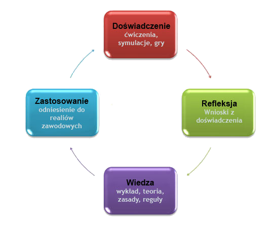

## 22. Technika Q-sort

- Polega na sortowaniu stwierdzeń pod względem pasowania do jakiegoś kryterium na kilkupunktowym kontinuum. Początek skali (oznaczmy ją umownie jako 1) oznacza zupełny brak zgodności, koniec skali (np.9) całkowitą zgodność. Tak też nazywa się zbiór pozycji, które podlegają sortowaniu.
- **Przykład.** Prosimy osobę badaną aby oszacowała w jakim stopniu pasują do niej następujące stwierdzenia: “lubię lody”, “myślę o lodach”, “fantazjuję o różnych deserach lodowych”, „lody są tuczące" itd.
- Zadaniem badanego jest ułożenie tych kartek na osobne kupki zgodnie z tym jak bardzo do niego pasują. Dodatkowo stosuje się pewne ograniczenia sortowania, tak aby rozkład twierdzeń przypominał w przybliżeniurozkład normalny-badany dowiaduje się, że powinien użyć wszystkich punktów kontinuum, najwięcej kartek powinno znaleźć się w środkowej części, skrajne powinny być używane rzadziej.

## 23. Analiza SWOT

Analiza SWOT polega na podzieleniu zebranych informacji na cztery grupy (cztery kategorie czynników strategicznych):

- **S** *(Strengths)* – mocne strony: wszystko to co stanowi atut, przewagę, zaletę,
- **W** *(Weaknesses)* – słabe strony: wszystko to co stanowi słabość, barierę, wadę,
- **O** *(Opportunities)* – szanse: wszystko to co stwarza szansę korzystnej zmiany,
- **T** *(Threats)* – zagrożenia: wszystko to co stwarza niebezpieczeństwo zmiany niekorzystnej.

## 24. Zdolności zawodowe a sukces w pracy

**Tiffin i McCormick (1973) wymieniają następujące cechy, stanowiące podstawę sukcesu w wykonywaniu najróżniejszych zawodów i zajęć (występujące w różnych konfiguracjach, ale zawsze mające poziom ponadprzeciętny):**

- Rozumienie słów (używanie testów słownikowych w wielu testach uzdolnień zawodowych)
- Ekspresja słowna
- Płynność wyobraźni
- Oryginalność myślenia
- Zdolność do zapamiętywania liczb
- Rozumowanie dedukcyjne i indukcyjne
- Porządkowanie informacji, giętkość myślenia
- Orientacja przestrzenna i wyobraźnia wzrokowa
- Fluencja słowna w czasie dyskusji, giętkość argumentowania, szybkość dyskutowania
- Uwaga selektywna
- Umiejętności gospodarowania czasem
- Szybkość spostrzegania
- Napięcie statyczne i dynamiczne
- Siła wyrzutu ramienia, wytrwałość fizyczna, giętkość ciała
- Czas reakcji prostej, czas reakcji z wyborem, szybkość ruchu poszczególnych części ciała
- Zręczność palców, rąk, tzw. stałość ręki i ramienia
- Kontrola szybkości ruchów, dokładność sterowani

`jezusie, jakie to nudne xD`

## 25. Kompetencje i kwalifikacje jako podstawy polityki personalnej

- Pojęcie kompetencji jest przedmiotem zainteresowań wielu nauk społecznych i prawa.
- Psychologowie podkreślają głównie fakt funkcjonalnego dopasowania człowieka do pracy oraz psychologiczne mechanizmy regulacji wzajemnych stosunków człowieka ze swym otoczeniem, zarówno fizycznym, jak i społecznym.
- W psychologii tzw. kompetencje społeczne nazywa się kompetencjami interpersonalnymi.

#### A. Kompetencje społeczne

*Wymienia się trzy najważniejsze modele kompetencji społecznych:*

- **Trójskłądnikowy model Cavella**: przystosowanie społeczne, funkcjonowanie społeczne i umiejętności społeczne. Przystosowanie społeczne możemy ocenić po sposobie funkcjonowania jednostki w sytuacjach społecznych, a umiejętności mogą być rozpoznane tylko w praktycznym ich stosowaniu, czyli w sposobie funkcjonowania człowieka w tego typu sytuacjach.
- **Model Argyle’a.** Kompetencje społeczne to opanowanie niezbędnych umiejętności pozwalających uzyskać u innych ludzi pożądane zachowanie w sytuacjach społecznych.Wśród owych umiejętności wymienia: asertywność, gratyfikacje i wsparcie, zdolność komunikowania werbalnego i niewerbalnego, zdolność empatii i współpracy, strategie rozwiązywania problemów i zdolność do adekwatnego zachowania się w różnych sytuacjach (plastyczność). Umiejętności te nabywane są w toku treningu społecznego (sytuacje intymne, sytuacje ekspozycji społecznej, sytuacje formalne, sytuacje wymagające asertywności [Matczak, 2001]).
- **Model ASC** (*Affective Social Competence*) oparty na teorii emocji. Zakłada istnienie 3 zintegrowanych ze sobą czynników: zapisywanie informacji afektywnych, odtwarzanie informacji afektywnych oraz doświadczanie afektu. Związany z koncepcją inteligencji emocjonalnej Golemana, podkreślającej konieczność orientowania się osoby we własnych emocjach, ich znajomości, kierowania nimi i rozpoznawania emocji u innych i podtrzymywania związków z innymi.

#### Kompetencje społeczne a dobór kandydatów:

- Wiedza o kompetencjach jest obecnie w doborze kandydatów na stanowiska kierownicze oraz do pracy w sytuacjach, w których konieczne jest wsparcie społeczne, np. pracownicy socjalni, pielęgniarki, lekarze, prawnicy, doradcy wszelkiego rodzaju i nauczyciele itp.
- **typy psychologicznych profili menedżerów:**
- **Menedżerowie odważni** : odwaga ich płynie z głębokiej identyfikacjiz działaniami organizacyjnymi.
- **Menedżerowie wyzwalający**: rzucają wyzwania, pragną odnowy organizacji, często wytykają dotychczasowe błędy, nastawieni są na konfrontację, sprzeciw wobec tego, co jest.
- **Menedżerowie niezadowoleni**: widzą beznadziejność sytuacji, brakuje im sił, ambicji, energii, chęci działania, odrzucają stan aktualny, lecz brakuje im sił, żeby coś zmienić.
- **Menedżerowie konformiści**: przejawiają wielką troskę o organizację, są wręcz patologicznie lojalni, nie potrafią zdobyć się na odwagę żeby coś zmienić. To co jest, uważają za najlepsze.

#### B. Kompetencje menedżerskie

**Obecnie największą popularnością cieszy się następująca lista kompetencji:**

- Umiejętności techniczne, zwiększanie aktywności własnej.
- Umiejętności radzenia sobie ze stresem.
- Umiejętności komunikowania się.
- Umiejętności rozwiązywana konfliktów.
- Umiejętność pracy z zespołem.
- Umiejętność wprowadzania zmian.
- Umiejętność zdobywania wpływu i władzy.

## 26. Mechanizmy regulacyjne zachowania się człowieka w miejscu pracy:

- **Praca jest aktywnością ukierunkowaną na zadania,** których realizacja ma się przyczynić do uzyskania określonych gratyfikacji, w głównej mierze materialnych.
- Przedmiotem zainteresowań psychologów pracy są mechanizmy ściśle związane z wymianą świadczeń, z interakcjami łączącymi się z wywieraniem wpływu lub z uleganiem wpływom innych ludzi i z rolą zaufania interpersonalnego w regulacji właśnie tych stosunków.
- Każdy pracownik rozpoczynając pracę w firmie poznaje zasady otrzymywania określonych świadczeń za wykonaną pracę, wie kto i jak będzie go kontrolował, ale że jak on sam będzie kontrolował swoich partnerów oraz na czym będzie polegała samokontrola.

#### Mechanizmy regulacyjne – kontrakt psychologiczny:

- **Kontrakt psychologiczny** jest pojęciem, które wyrosło z problematyki wymiany społecznej, z badań nad słusznością płacy i rolą wynagrodzenia w podejmowaniu przez pracownika decyzji o większym zaangażowaniu w pracę i w realizowanie organizacyjnych celów.

## 27. Percepcja kontraktu psychologicznego

**3 rodzaje sytuacji** (Lester, Turnleyi inni, 2002):

- **Sytuacje zgodności versus niezgodności między dwiema stronami kontraktu.** Po przez identyfikację obszaru, w którym obustronne obietnice nie są respektowana można prognozować konflikty, co może służyć precyzowaniu nowego kontraktu.
- **Sytuacje, w których różnice w spostrzeganiu kontraktu wpływają na postawy i zachowania**, zarówno przełożonych jak i pracowników wobec pracy i siebie. Ważne pytanie: jak fakt złamania kontraktu wpływa na zaangażowanie i rzeczywistą wydajność pracy obu stron.
- **Sytuacje, w których istnieją różnice atrybucji przyczyn łamania kontraktu**, których dokonują pracownicy i przełożeni oraz stopień w jakim obie strony przypisują intencjonalność w łamaniu kontraktu psychologicznego.

**Wnioski z badań** :

- Pracownicy są bardziej skłonni do dostrzegania niedotrzymywania warunków kontraktu psychologicznego (płace, awanse, dobre stosunki w pracy), lecz nie różnią się w ocenie wysokości premii, ilości wykonanej pracy oraz źródeł wsparcia. Pracownicy nawet wyżej oceniają wypełnianie warunków kontraktu niż ich przełożeni.
- Spostrzeganie faktów naruszenia kontraktu psychologicznego wpływa zarówno na obniżenie nastrojów, jak i na obniżenie wskaźników wydajności pracy.
- Pracownicy bardziej niż ich przełożeni skłonni są traktować przypadki łamania kontraktu przez przełożonych jako niedotrzymywanie obietnic i wycofywanie się z nich.
- Przełożeni fakt pokrzywdzenia pracownika przez firmę przypisują czynnikom leżącym całkowicie poza organizacją (np. złe prawo).

## 28. Konflikt w organizacji jako mechanizm regulacyjny

**Konflikty uważa się za zjawiska naturalne w każdej organizacji i w każdej zbiorowości, gdyż:**

- W każdej społeczności istnieją grupy i osoby mające rożne, często sprzeczne interesy, wynikające np. z nierównego podziału pracy, niewłaściwej alokacji dóbr będących w dyspozycji danej organizacji itp.
- Każda organizacja dysponuje z reguły ograniczoną ilością zasobów, będących do podziału w zamian za wkład, jaki wnoszą do organizacji jej poszczególni członkowie.
- Pracownicy często mają wygórowane aspiracje i oczekiwania w stosunku do samych siebie, a także do przedsiębiorstwa. Uważają, że ich praca jest warta więcej, niż to co za nią otrzymują (zawyżona samoocena).
- Instytucje stawiają niekiedy nieuzasadnione wymagania pracownikom zajmującym określone stanowisko pracy, gdyż ciągle brakuje obiektywnych metod wyceny (wartościowania) pracy (np.pracy twórczej, szczególnie odpowiedzialnej, wysoko płatnej w firmach konkurencyjnych itp.)

## 29. Konflikt w organizacji – symptomy:

- **Niezadowolenie pracowników.** Wysuwanie roszczeń pod adresem pracodawcy (mogą być uzasadnione lub mieć charakter roszczeniowy)
- **Skargi i zażalenia pracowników**, przekazywane za pośrednictwem organów uprawnionych do interwencji (sądy koleżeńskie, samorządy pracownicze, inspekcja pracy, związki zawodowe itp.)
- **Anonimy i donosy** przekazywane instancjom nadrzędnym, uprawnionym do sprawowania nadzoru i kontroli
- **Złośliwe uwagi krytyczne**, ironiczne komentarze, demonstracyjne nieobecności lub ostentacyjne opuszczanie gremiów, by wyrazić protest.
- **Akty agresji**, gwałtu, pobicia i rękoczyny, najbardziej drastyczne i najmniej cywilizowane formy walki, które mogą się zdarzyć w miejscach publicznych i w pracy.

## 30. Konflikty w pracy

- Wielką sztuką personelu zarządzającego daną firmą jest umiejętność utrzymania optymalnego poziomu konfliktu, ponieważ wówczas jest on źródłem tzw. twórczych rozwiązań.
- Wymaga to nieustannego czuwania, tak by aspekt zadaniowy, funkcjonalny nie został zdominowany przez cele uboczne, pozazadaniowe, prywatne interesy uczestników konfliktu.

## 31. Rekrutacja i selekcja pracowników

**Rekrutacja to pierwszy etap poszukiwania kandydatów do pracy, który służy zebraniu odpowiedniej grupy osób, spełniających wymagania do pracy na określonym stanowisku.**

- **Przykładowe klasyfikacje: podział rekrutacji ze względu na stopień zaangażowania pracodawcy w poszukiwania pracowników:**
- **Bierne formy rekrutacji** – osoby zainteresowane pracą w danej firmie same przesyłają dokumenty aplikacyjne, nawet, gdy aktualnie nie ma wolnego stanowiska pracy. Sam pracodawca w tej sytuacji nie podejmuje żadnych działań w celu poszukiwania przyszłych pracowników.
- **Aktywne bezpośrednie formy rekrutacji** – są to metody, gdzie firma dokonuje wysiłku, by znaleźć osoby chętne do podjęcia w niej pracy. Mogą to być ogłoszenia w prasie, mediach, upowszechnianie ofert podczas dni kariery, targów pracy, giełd pracy.
- **Aktywne pośrednie formy rekrutacji** – wykorzystując tę formę, pracodawca zleca poszukiwanie pracowników firmom zewnętrznym, takim jak agencje doradztwa personalnego czy agencje pośrednictwa pracy.

## 32. Selekcja pracowników

**Do najczęściej wykorzystywanych metod można zaliczyć**:

- analizę życiorysu i ankiet biograficznych
- rozmowę kwalifikacyjną
- testy psychologiczne
- testy wiedzy
- centra oceny – *assessment centre*
- techniki symulacyjne

## 33. Stres zawodowy

#### Problematyka stresu w pracy:

- Dorosłe osoby poświęcają średnio około 25% aktywności życiowej na pracę zawodową.
- praca jest także jednym z najczęstszych i największych źródeł stresu oraz miejscem doświadczania negatywnych emocji.
- Nie istnieją oddzielne koncepcje stresu „ogólnego” i stresu w pracy.
- Kanter (1977) stwierdził, że działania związane i niezwiązane z pracą są powiązane ze sobą, jeśli chodzi o ich efekty psychologiczne, fizjologiczne i zdrowotne.
- Oddzielanie dwóch sfer: praca i poza pracą zostało nazwane przez Kantera „mitem oddzielnych światów”.
- Nie jest prawdą, że praca wywiera wyłącznie negatywny wpływ na zdrowie. Istnieją dowody świadczące o tym, że stres nie musi mieć następstw patologicznych.
- Reakcje wielu osób na doświadczenie stresu, zarówno natury psychologicznej, jak i fizjologicznej, mieszczą się w granicach homeostazy organizmu i mimo obciążenia dla mechanizmów psychofizjologicznych, nie muszą powodować długotrwałych zaburzeń.
- Tak więc, mimo że stres zawsze obniża dobre samopoczucie, niekoniecznie musi przyczyniać się do powstawania zaburzeń fizycznych lub psychicznych.
- Zgodnie z podejściem psychologicznym (w odróżnieniu od podejścia inżynieryjnego i fizjologicznego) **stres** w kontekście pracy definiowany jest jako **dynamiczna interakcja między człowiekiem a środowiskiem pracy.**

`tu nastąpiło teoria stresu Lazarausa, Strelaua i kogoś tam jeszcze, ale mi się nie chcę wnikać, sorki`

#### Symptomy przeżyć i napięć wewnętrznych:

- nagle wybuchy niekontrolowanej agresji
- celowe próby zmiany oczekiwań związanych z rolą
- przerzucanie konfliktu na innych
- zachowanie nonkonfornistyczne w organizacji, wycofanie lub bunt

#### Wielka trójka negatywnych emocji:

##### **DEPRESJA**

*Nieprzyjemne emocje są tak samo toksycznym czynnikiem ryzyka jak palenie, wysoki poziom cholesterolu w odniesieniu do chorób serca.*

- **SCHEMAT STRESU**:
- *życiowe wydarzenia/ lęk/ interpretacja psychologiczna*:
- Reakcja na stres - *Poziom fizjologiczny*
- Reakcja na stres - *Poziom Psychologiczny - emocjonalny*
- Reakcja na stres - *Poziom behawioralny*
- **Wpływ czynników stresogennych w pracy na zdrowie**:
- **Czynniki obiektywne** (biologiczne, fizyczne, chemiczne) - Bezpośredni wpływ na zdrowie
- **Czynniki psychospołeczne** - Wpływ na zdrowie za pośrednictwem mechanizmu stresu

`Tam ogólnie jest potem w pizdu jakiś schematów, ale wszystkie mówią to samo, że` `na proces stresu wpływają czynniki zewnętrzne, ale też indywidualne cechy` `jednostki (jak np. to jak sb z nim radzi) i to wszystko daję stres, który wpływa na zdrowie`

#### Skutki stresu w pracy:

- Jeśli stres pojawia się często, organizm pozostaje w stanie silnego pobudzenia fizjologicznego i wysokiej gotowości mobilizującej organizmu.
- Przedłużający się stres sprzyja rozwojowi zaburzeń psychosomatycznych (choroba wieńcowa, wrzody żołądka, alergie, bóle głowy i kręgosłupa, w pewnym stopniu również choroby nowotworowe) oraz obniża odporność organizmu.

#### Stres w pracy a czynniki psychospołeczne:

- W ostatnich dziesięcioleciach zaszły poważne zmiany, bezpośrednio związane z organizacją i zarządzaniem procesem pracy (EU-OSHA, 2007).
- Pojawienie się nowych zagrożeń i nowych wyzwań w obszarze ochrony pracy.
- Zagrożenia psychospołeczne w pracy zostały uznane za istotne nowe czynniki ryzyka (EU-OSHA, 2007; NIOSH, 2002).
- Stres zawodowy oraz przemoc w miejscu pracy, związane z psychospołecznymi czynnikami ryzyka, uznawane są za główne wyzwania dla bezpieczeństwa i higieny pracy (EU-OSHA,2007).

## 34. Definiowanie psychospołecznych czynników ryzyka

- Zagrożenia psychospołeczne to każdy rodzaj bodźca/sytuacji, który oddziałuje na człowieka na drodze mechanizmów psychologicznych, powodując szkodę w postaci zakłóceń w dobrym funkcjonowaniu i zaburzeń zdrowia.
- Ryzyko związane z czynnikami psychospołecznymi to prawdopodobieństwo, ze ujawni się potencjał szkodliwości i możliwy zakres szkód wywołanych przez te czynniki (Cox i Griffiths, 2006, Luksemburg).
- Międzynarodowa Organizacja Pracy definiuje zagrożenia psychospołeczne w kategoriach interakcji pomiędzy treścią pracy, organizacją i zarządzaniem procesem pracy oraz innymi **organizacyjnymi i środowiskowymi uwarunkowaniami z jednej strony, a kompetencjami i potrzebami pracownika z drugiej** (ILO, 1986).
- Prostsza definicja: **te aspekty projektowania i zarządzania procesem pracy** wraz z ich kontekstem społeczno-organizacyjnym, które potencjalnie mogą spowodować szkody psychologiczne lub fizyczne (Cox i Griffiths, 2005).

## 35. Zagrożenia zawodowe:

##### Każdy czynnik, który może spowodować wystąpienie szkody:

- **fizyczne** (biologiczne, biomechaniczne, chemiczne i radiologiczne)
- **Psychospołeczne**: *Jeżeli oddziaływanie ma charakter bezpośredni, fizykochemiczne, to mówimy o zagrożeniach fizycznych.
- Jeżeli natomiast oddziaływanie ma charakter psychofizjologiczny, pośredni (mechanizmem pośredniczącym jest stres), to mowa o zagrożeniach psychospołecznych.
- Zagrożenia psychospołeczne to stresory zawodowe lub inaczej źródła stresu w pracy.

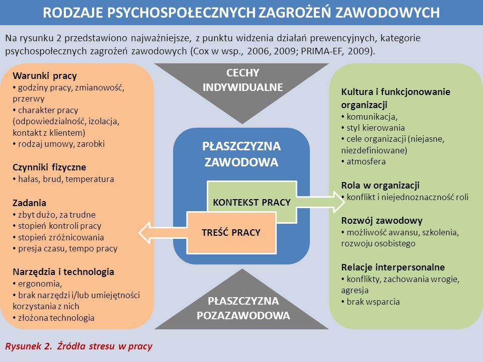

## 35. Raport ILO – psychospołeczne czynniki zagrażające zdrowiu pracownika:

- **Czynniki fizyczne** (hałas temperatura)
- **Czynniki związane z pracą** (przeciążenie pracą –ilościowe i jakościowe, monotonia)
- **Rozkład czasu pracy** (godziny pracy, zmianowość)
- **Czynniki organizacyjne i wynikające z kierowania – pełnionej roli** (brak swobody w podejmowaniu decyzji)
- **Stosunki w pracy** (ich jakość, wsparcie społeczne)
- **Zmiany w środowisku pracy**
- **Czynniki wynikające z zmian technologicznych** (konieczność przystosowania lub wyszkolenia)
- **Inne** (niepewność pracy, poczucie odpowiedzialności za utrzymanie rodziny)

## 36. Stres zawodowy po raz 2567890

- Ryzyka psychospołeczne są nieodłącznie związane z doświadczaniem stresu zawodowego.
- Stres zawodowy jako reakcja organizmu człowieka może wystąpić w sytuacji, gdy jednostka eksponowana jest na związane z pracą wymagania i presję, które nie są dostosowane do jej wiedzy i umiejętności oraz stanowią wyzwanie z punktu widzenia jej zdolności do poradzenia sobie(WHO,2003).
- Ponadto, w wyniku narażenia na niekorzystne psychospołeczne warunki pracy i doświadczania wynikającego z nich stresu zawodowego, coraz powszechniejszy staje się także problem wypalenia zawodowego.

`potem jest o tym jak ludziom się ten stres dzieję w Europie, jak kogoś to interesuję to niech se obczai`

## 37. Narażenie na ryzyka psychospołeczne – mechanizmy:

**Konsekwencjami zmieniającego się charakteru pracy jest wzrastające narażenie na psychospołeczne czynniki ryzyka oraz pojawianie się nowych zagrożeń, które muszą zostać zidentyfikowane aby możliwe było zredukowanie ryzyka jakie niosą one dla zdrowia i bezpieczeństwa pracy** (EU-OSHA, 2007).

- Wyniki badań wskazujące na związek pomiędzy zgłaszaniem skarg na utratę zdrowia w związku z pracą a narażeniem na psychospołeczne czynniki ryzyka oraz na interakcje między zagrożeniami fizycznymi i psychospołecznymi skutkującymi negatywnymi konsekwencjami zdrowotnymi na poziomie indywidualnym i organizacyjnym (Cox, Griffiths i Rial-Gonzalez, 2000).
- Szczególnie zagrożenia psychospołeczne w miejscu pracy okazały się mieć potencjalny szkodliwy wpływ na zdrowie psychiczne, somatyczne i społeczne pracowników
- Coraz większa liczba dowodów naukowych wskazuje zarówno na bezpośredni jak i pośredni wpływ psychospołecznych warunków pracy na wskaźniki kondycji organizacji (takie jak: absencje, w tym chorobowe, produktywność, satysfakcja z pracy oraz zamiar odejścia)

## 37. Stres zawodowy

`kto by się spodziewał XD`

**Ganster i Schaubroeck**:

- brak jednoznacznych dowodów naukowych na istnienie związków stresu zawodowego ze skutkami zdrowotnymi
- istnieją pośrednie dowody wskazujące na występowanie efektu stresu zawodowego, pochodzące z badań warunków pracy i wskazujące na różnice w stanie zdrowia i śmiertelności, niewystarczająco wyjaśniane przez inne czynniki
- istnieją również badania podmiotowe wskazujące na związek przyczynowo-skutkowy między sytuacją zawodową a reakcjami psychologicznymi i emocjonalnymi.
- Europejska Agencja ds. Bezpieczeństwa i Zdrowia w Pracy także doszła do podobnych wniosków (EU-OSHA, 2000).
- Zagrożenia psychospołeczne mogą wpływać zarówno na zdrowie psychiczne, jak i somatyczne, w sposób bezpośredni lub pośredni poprzez mechanizm stresu, za pośrednictwem modelu dwutorowego oddziaływania ryzyko-szkoda.

## 38. Wypalenie zawodowe

##### Proces wypalenia zawodowego

- Konsekwencja destrukcji zachodzącej w psychice osób nadmiernie eksploatujących swoje siły w dawaniu siebie innym.
- Dotyczy zawodów społecznych i usługowych zarazem, gdzie przedmiotem oddziaływań są relacje interpersonalne, polegające na wymianie emocjonalnej i zaangażowaniu.
- W literaturze anglojęzycznej tę grupę zawodów określa się mianem human service professions lub też w skrócie helping professions .
- **PARADOKS** - te same właściwości zawodowe mogą być źródłem ogromnej satysfakcji i jednocześnie stać się powodem dużych obciążeń i stresu, a w konsekwencji rozwoju zespołu wypalenia zawodowego.

#### A. Proces wypalenia zawodowego –model stresu Lazarusa i Folkman

**Objawy wypalenia występują u osób pracujących w warunkach przewlekłego stresu społecznego, który jest rozumiany jako:**

- sekwencja interpretacji i wartościowania stresorów (ocena pierwotna),
- ocena własnych kompetencji i zasobów (ocena wtórna)
- ocena skuteczności zmagania się (własna aktywność zaradcza)
- **W tej koncepcji widać, że mechanizm wypalenia zawodowego działa na zasadzie błędnego koła przyczyn i skutków**

#### B. Koncepcja wielowymiarowego wypalenia zawodowego (Maslach)

- **Powiązanie trzech wymiarów:**
- *Emocjonalne i psychofizyczne wyczerpanie*: bezsilność, brak energii, osłabienie, zmęczenie, drażliwość, konfliktowość
- *Depersonalizacja*: przedmiotowe traktowanie, cynizm, obojętność, rutyna, traktowanie pacjenta jako kolejnego przypadku, zmiana opieki na nadzór, unikanie kontaktu;
- *Obniżona satysfakcja zawodowa:* postrzegania siebie jako osoby nieefektywnej, niekompetentnej, z poczuciem braku osiągnięć i sukcesów, utraty sensu tego, co się robi.

#### C. Zjawisko wypalenia zawodowego wśród personelu medycznego

*Efekt trudnej sytuacji, w której czynniki środowiskowe mają duże znaczenie*

- **Podstawowe uwarunkowania WZ:**
- *Poczucie braku kontroli prowadzące do wyczerpania emocjonalnego.* **Przykład**: w codziennej pracy pielęgniarka ma ograniczony wpływ na powrót do zdrowia i współpracę z pacjentami. Dodatkowym obciążeniem są zmienne decyzyjne lekarskie i administracyjne co w konsekwencji rodzi konflikty.
- *Niepewność związana z wykonywaniem zadań zawodowych.* Wynika ona z poczucia wątpliwości odnośnie własnych umiejętności.
- *Poczucie niespełnienia oczekiwań.* Szczególnie widoczne jest w dysproporcji pomiędzy tym, co inwestują w pacjentów, a tym, co otrzymują.
- *Stres pracy zmianowej.* Wynikający głównie z zaburzenia rytmu okołodobowego i wymagań stałej gotowości, wysokiego profesjonalizmu niezależnie od pory dnia.

#### C1. Wypalenie zawodowe u pracowników oddziałów onkologicznych

- Oglądanie śmierci jest dla większości niezwykle dotkliwym doznaniem emocjonalnym (smutek po stracie, gniew, bezradność).
- Częste obcowanie ze śmiercią wywiera ogromny wpływ na personel medyczny.
- Krańcowe zmęczenie fizyczne i emocjonalne, negatywny bądź wrogi stosunek do innych osób lub brak inicjatywy.
- Popadanie w stany znużenia i depresji, manifestujące się w nadużywaniu alkoholu, zaostrzonym nałogu tytoniowym, lekomanii, narkomanii.
- Często obserwuje się zmiany o charakterze nowotworowym (Maslach i Jackson, 1982).

## 39. Komunikacja w pracy

**Komunikacja jest dwustronnym przekazywaniem informacji, idei, uczuć za pomocą symboli werbalnych i niewerbalnych**

`no shit, Sherlock XD`

#### Komunikacja interpersonalna

- jest czymś, co wydarza się pomiędzy ludźmi, a nie tylko czymś, co jedna osoba przekazuje za pomocą słów bądź gestów drugiej osobie (dynamiczny proces). interpersonalnaJohn Stewart definiuje komunikację interpersonalną jako:

> taki typ, jakość lub rodzaj kontaktu, który pojawia się kiedy osoby mówią lub słuchają w sposób maksymalizujący to, co osobiste.

## 40. Kierowanie ludźmi - przewodzenie

- **Funkcje kierownicze**:
- Planowanie
- Organizowanie
- Kontrolowanie
- **Psychologiczne właściwości skutecznych działań kierowniczych:**
- Asertywność
- Motywacja
- Twórczość
- Krytycyzm
- Ekstrawersja
- Brak zniekształceń patologicznych - dewiacji

## 41. Komunikacja w grupie zadaniowej

- Osiągnięcie wspólnego celu nadrzędne wobec celów i potrzeb indywidualnych.
- Wymaga większej współpracy i lepszego wzajemnego dostosowania niż rozmowa w warunkach bardziej kameralnych.
- Struktura dyskusji w grupach często opiera się na sztywnych zasadach – obrady vs swobodna przyjacielska rozmowa.
- Określona struktura ma swoje uzasadnienie: służy studzeniu emocji, pozwala dojść do głosu opozycji oraz systematycznie przybliża dyskusję do rozwiązania.

## 42. Jak zostać liderem?

`bardziej interesowałoby mnie jak zostać dilerem, ale ok.`

- Aby skutecznie kierować pracownikami –podwładnymi należy najpierw nauczyć się kierować sobą i postępować optymalnie.
- Żeby móc poznać ludzi –trzeba poznać siebie
- Aby oceniać innych – najpierw oceń siebie
- Jeśli chcesz rozpoznać czyjeś emocje –musisz poznać swoje emocje i mieć je nazwać

`XD co to za kołczingowe bzdury są`

**Lider doskonały**:

- Liderzy nie rodzą się, lecz kształtują
- Możesz nauczyć się pełnić kierowniczą funkcje
- Nie można być liderem w osamotnieniu; potrzebujesz tych, którzy potrzebują przywódcy
- Przewodzenie wiąże się z wyrazami szacunku, a niekoniecznie sympatii
- Musisz znaleźć własny sposób przewodzenia
- Liderzy uczą się, dojrzewają, poznają samych siebie i wiedzą, czego chcą

**“Wielka siódemka” (zasady sprawowania kierowniczej funkcji)**

- Wnikliwość
- Unicjatywa
- Inspiracja
- Zaangażowanie
- Improwizacji
- Indywidualność
- Realizacja

## 43. Role w grupach zadaniowych

- **Członkowie**:
  - **inicjatorzy** - zabierają głos pierwsi. Inicjują dyskusje, dostarczając faktów, dzielą się odpowiednimi informacjami i doświadczeniami oraz wypowiadają swoje opinie
  - **respondenci** - słuchają i reagują na to, co słyszą, podsumowując i rozwijając dany temat. Oceniają informacje, krytykują propozycje oraz zadają pytania.
- Przez cały czas trwania dyskusji członkowie grupy na zmianę inicjują i reagują na treść. Obie role są równie ważne i niezbędne w zachodzącym procesie.
- Niekiedy jednak równowaga tych ról może zostać zaburzona.
- Utrzymanie równowagi jest jednym z zadań lidera grupy.
  - **Liderzy** - rożne role lidera, w zależności od sytuacji i potrzeb grupy:
- jest organem wykonawczym (ustala zasady, plan zebrań, terminy spotkań)
- planuje
- ustala politykę grupy (wskazówki dla zarządu, ogólne zasady)
- jest ekspertem
- jest przedstawicielem grupy na zewnątrz (reprezentuje grupę wobec świata zewnętrznego)
- wpływa na relacje pomiędzy członkami grupy (łączy i rozdziela poszczególne osoby, awansuje i degraduje)
- przyznaje nagrody i wymierza kary (chwali, krytykuje, za zasługi przydziela funkcje i role zadaniowe)
- jest arbitrem
- jest przykładem (służy jako wzorzec właściwego zachowania w grupie)

## 44. Bariery utrudniające komunikacje w grupach zadaniowych:

**Zapominanie o właściwej hierarchii potrzeb w grupie.**

- **Agresorzy** – atakowanie innych członków grupy; własna wygrana ważniejsza od sukcesu grupy.
- **Defetyści** - przekonani, że istniejących problemów nie da się rozwiązać. Sabotowanie postępu.
- **Gwiazdy** – skupianie na sobie całej uwagi grupy.
- **Gawędziarze** – skupianie się na sprawach marginalnych i nieistotnych.
- **Klowni** – chęć zabawiania i innych jest ważniejsza niż cel grupy.
- **Zwierzchnicy** – wolą rządzić niż rozwiązywać problemy.
- **Fanatycy** – odnoszenie wszystkiego do własnej obsesji, niezależnie od tego jaki jest cel grupy.

## 45. Zasady skutecznego funkcjonowania grup zadaniowych

`jezu jakie banały to są nie mam na to słów`

- Ustal cel spotkania grupy.
- Uświadom sobie swoje opinie.
- Słuchaj.
- Bierz czynny udział.
- Zachowaj zimna krew.

## 46. Mobbingi dyskryminacja w miejscu pracy

> Mobbing to długotrwały (co najmniej przez 6 miesięcy, co najmniej raz w tygodniu) terror psychiczny stosowany w pracy wobec jednostki.

> Mobbing to rodzaj terroru psychicznego, stosowanego przez jedną lub kilka osób przeciwko (przeważnie) jednej osobie. Molestowanie psychiczne powtarza się systematycznie zaś osoba maltretowania pozbawiona jest możliwości obrony. W tej sytuacji bezradności i bezsilności pozostaje tak długo, jak długo utrzymują się działania mobbingowew jej kierunku.

#### MOBBING TO PROCES:

- Przemocy i nękania (dręczenia) psychicznego pracownika
- Trwający długo i systematycznie
- Godzący w godność i integralność człowieka
- Mający na celu: poniżenie, ośmieszenie, zaniżenie samooceny, wyeliminowanie lub odizolowanie pracownika od współpracowników

#### Przyczyny mobbingu:

**Wymienia się następujące grupy przyczyn sprzyjających wystąpieniu u mobbingu**:

- przyczyny społeczne,
- cechy zarządzającego organizacją, *szczególna pozycja społeczna ofiary mobbingu.

#### Miejsce występowania:

- Z przemocą psychiczną mamy do czynienia tam, gdzie ludzie przebywają ze sobą w grupie przez dłuższy czas –w szkole, wyższej uczelni, w miejscu pracy, w stowarzyszeniach i wspólnotach a także w rodzinie.

#### Narzędzia jakimi posługuje się mobbing to:

- szykany, zwodzenie, podstęp i intryga, kłamstwa, plotki, oszczerstwa, zachowania sadystyczne. Ich wystąpieniu sprzyja taka organizacja pracy, gdzie osobę traktuje się instrumentalnie.

**Pojęcie *bullying* zarezerwowane jest dla opisania zjawisk przemocy w szkole, w grupach dzieci i młodzieży, gdzie poza agresją psychiczną występują akty przemocy fizycznej, która w przypadku mobbingu jest spotykana bardzo rzadko.**

#### FAZY MOBBINGU:

- **Faza wczesna z fazą rozszerzania się mobbingu**:
- Faza powstawania nierozwiązywanych konfliktów. Osoba, która zaczyna być poddawana mobbingowipodejmuje racjonalne, choć nieskuteczne próby przyczynienia się do złagodzenia czy rozwiązania konfliktu.
- Pojawienie się typowych działań mobbingowych.
- Pojawienie się przewlekłego złego samopoczucia ofiary i codzienny strach przed pójściem do pracy oraz ciągłe stany napięcia nerwowego prowadzące do reakcji stresowej.
- Organizm wysyła sygnały alarmowe -bóle głowy, bóle brzucha, bóle za mostkowe. Z czasem do objawów dołączają: Nudności, wymioty, wzrost ciśnienia tętniczego krwi, bezsenność, zaburzenia koncentracji i stany lękowe oraz depresyjne.
- Często nadużywanie alkoholu przez ofiarę, leków uspokajających czy nasennych lub Innych używek.
- **Faza “stabilnego mobbingu”**
- trwale wyznaczenie roli “kozła ofiarnego”.
- Stygmatyzacja, zakwalifikowanie jako: mądrala, kłamca, krętacz, nadwrażliwiec lub pieniacz.
- Przełożony stosuje: niesprawiedliwe napomnienia, straszenie, degradację pozycji w grupie przez przydzielanie mniej ważnych zadań, często poniżej kompetencji i umiejętności.
- Ciągłe nieuzasadnione pretensje i oskarżenia w środowisku pracy, poczucie całkowitej bezsilności, może u niektórych z prześladowanych osób wyzwolić zachowania agresywne.
- Są one jednak kładzione na karb dziwności nadwrażliwca, pieniacza i odmieńca, a więc nie spełniają roli obronnej.
- Objawy i dolegliwości psychosomatyczne zaostrzają się i bezwzględnie wymagają interwencji lekarskiej. Mogą się rozwinąć choroby takie jak: choroba wrzodowa, zawał mięśnia serowego, udar mózgu, astma oskrzelowa.
  - **Faza zaawansowana**:
- Poszkodowana osoba nie potrafi sprostać stawianym jej wymaganiom zawodowym i społecznym.
- Świadomość tego faktu oraz zagrożenie utratą pracy a co za tym idzie pozycji społecznej i środków do życia powoduje stany depresyjne lub, przeciwnie, niekontrolowane wybuchy wściekłości i agresji kierowanej przeciwko współpracownikom. Dalsze zatrudnienie na zajmowanym stanowisku jest niemożliwe, teraz już z przyczyn obiektywnych.
- Co dziesiąty pracownik ma w zaawansowanej fazie mobbingumyśli samobójcze a co setny podejmuje próbę samobójczą.
- Schorzenie, opisywane przez psychiatrów jako potraumatycznestany lękowe (PTSD-posttraumaticstressdisorder) występujące u takich osób porównywane jest przez specjalistów do stanu, jaki opisywano u osób, które przeszły doświadczenie obozu koncentracyjnego.
  - **Faza zaawansowana**:
- Poszkodowana osoba nie potrafi sprostać stawianym jej wymaganiom zawodowym i społecznym.
- Świadomość tego faktu oraz zagrożenie utratą pracy a co za tym idzie pozycji społecznej i środków do życia powoduje stany depresyjne lub, przeciwnie, niekontrolowane wybuchy wściekłości i agresji kierowanej przeciwko współpracownikom. Dalsze zatrudnienie na zajmowanym stanowisku jest niemożliwe, teraz już z przyczyn obiektywnych.
- Co dziesiąty pracownik ma w zaawansowanej fazie mobbingumyśli samobójcze a co setny podejmuje próbę samobójczą.
- Schorzenie, opisywane przez psychiatrów jako potraumatycznestany lękowe (PTSD-post traumatic stress disorder) występujące u takich osób porównywane jest przez specjalistów do stanu, jaki opisywano u osób, które przeszły doświadczenie obozu koncentracyjnego.

## 47. Bezrobocie i pracoholizm

- **Bezrobocie jako kwestia społeczna** – dotyczy dużych grup społecznych, jest odbierana przez tę grupę jako nieprawidłowe, zakłóca jej prawidłowy rozwój, wywołuje społeczny niepokój, jest źródłem napięć społecznych. Nie może być w pełni rozwiązane w ramach grupy przy wykorzystaniu dostępnych jej metod i możliwości, może być rozwiązane tylko drogą podjęcia szerokich działań przez państwo.
- Bezrobotny to człowiek, który chce pracować i aktywnie poszukuje pracy, ale nie może utrzymać zatrudnienia przy istniejących stawkach płacy.

`w jakim świecie niby XD`

- Wyróżniamy dwa rodzaje bezrobocia:
- **bezrobocie dobrowolne** - spowodowane jest tym że część pracowników poszukujących pracy nie akceptuje poziomu płacy realnej są skłonni pracować przy wyższej stawce, a pracodawcy gotowi są ich zatrudnić poniżej płacy realnej. Zjawisko to jest głównym powodem powstawania tej odmiany bezrobocia gdzie preferencje siły roboczej nie pokrywają się z rachunkiem opłacalności pracodawców
- **bezrobocie przymusowe** - czyli niezależne od zachowania bezrobotnych. Ekonomia klasyczna tłumaczy je tym, że istnienie ustawowej gwarancji płacy minimalnej, zafałszowuje sygnały na rynku pracy, stan równowagi rynkowej zostaje zniekształcony, nawet przy spadku cen i popytu, wzroście bezrobocia, place i tym samym koszty nie maleją, poprzez strajki związki zawodowe wymuszają stawki powyżej wolnej ceny rynkowej

#### Podział bezrobocia ze względu na przyczyny:

- **bezrobocie strukturalne** - które charakteryzuje się zastojem gospodarczym i nowe roczniki napływające na rynek pracy nie mogą jej znaleźć. Istnienie wiec samego zjawiska bezrobocia tłumaczone jest tym że chęć podjęcia pracy i zgłoszonej jej podaży nie daje się w pełni urzeczywistnić
- **bezrobocie technologiczne** – wynika ze zmiany techniki, technologii, oraz z zastąpienia pracy żywej pracą maszyn,
- **bezrobocie koniunkturalne** - Keynesowska teoria przymusowego bezrobocia przyjmuje że jest ono wywołane zbyt małym popytem konsumpcyjnym i inwestycyjnym, który powoduje zbyt małe wykorzystanie zdolności produkcyjnych, poziom popytu stale ulega wahaniom, czyli jest zależny od koniunktury, stad nazwa bezrobocia. W fazach wysokiej koniunktury popyt rozszerza się i bezrobocie spada nawet do poziomu bezrobocia naturalnego.
- **bezrobocie frykcyjne** - obejmujące również ludzi zmieniających prace, przejściowo jej poszukujących z rożnych powodów.
- **bezrobocie sezonowe** – uzależnione od pór roku (np. budownictwo)
  - Ze względu na formę występowania bezrobocia wyróżniamy:
- **bezrobocie krótkookresowe** - do 3 miesięcy bez zatrudnienia.
- **bezrobocie średniookresowe** – od 3 do 12 miesięcy bez zatrudnienia.
- **bezrobocie długookresowe** – dotyczy osób. które pozostają bez pracy od 6 do 12 miesięcy.

*To ostatnie może przekształcić się w **bezrobocie długotrwałe**, bowiem czym dłuższa przerwa w pracy, tym maleją szanse na ponowne jej uzyskanie. Rosnące wymagania pracodawców, zmiany technik i organizacji pracy, konieczność uzupełniania kwalifikacji lub w ogóle zmiany zawodu nie sprzyjają skracaniu okresu pozostawania bez pracy*

**Dłuższe pozostawanie bez pracy powoduje, że ewentualni kandydaci stają się, ze względu na dezaktualizację swoich wiadomości i doświadczeń, mało interesujący dla pracodawców.**

```
 * Ponadto wyróżniamy:
```

- **bezrobocie ukryte** –rozumiane jako bezrobocie wśród zatrudnionych. Dotyczy ludzi nie ujętych w statystykach bezrobocia, ponieważ nie rejestrują się w urzędach pracy. Osoby te posiadają dochód, ale nie mają zawartego stosunku ubezpieczeniowego. Występuje głównie na wsi (nadmiar rąk do pracy, dawniej –przerost administracji).
- **bezrobocie jawne** – zarejestrowane (da się określić).

### Pracoholizm

> To obsesyjno-kompulsyjna forma zaburzeń zachowania, przejawiająca się w przymusie nieustannego zaangażowania w pracę lub inną aktywność o charakterze pracy

(Wojdyło, 2005)

```
* W zależności od przyczyn wyróżniamy:
```

- **Pracoholizm osobowościowy** – chroniczne uzależnienie, związane z obsesyjno-kompulsyjnymtypem osobowości i charakterystycznymi dla niej cechami psychicznymi (upór, ambicja, perfekcjonizm, samokontrola, sztywność, drobiazgowość)
- **Pracoholizm sytuacyjny** (tzw. pseudopracoholizm), który ma charakter przejściowy (trwa do czasu oddziaływania stresorów), reaktywny i strategiczny (bazuje na mechanizmach radzenia sobie z sytuacja trudną)

##### Właściwości pracoholizmu:

- Wewnętrzny przymus pracy związany z cechami osobowości obsesyjno-kompulsyjnej(anankastycznej), który sprawia, że mała ilość pracy odczuwana jest jako przeciążenie
- Przeciążenie pracą (lecz nie obciążenie nią)
- Odniesienie do każdej aktywności ukierunkowanej na cel, postrzeganej przez jednostkę jako praca
- Odniesienie do różnych pozycji zawodowych (nie tylko kierowniczych)
- Obecność fizjologicznego komponentu –uzależnienie od adrenaliny wyzwalanej w sytuacji stresu
- Występowanie objawów psychosomatycznych –bóle i zawroty głowy, zmęczenie, alergie, dolegliwości żołądkowe, tiki nerwowe.

##### Klasyfikacja pracoholizmu

(Robinson, Wojdyło, Frąszczak)

- **Niestrudzeni, nieustępliwi pracoholicy** – to perfekcjoniści, odczuwający silny przymus pracy, realizujący równocześnie wiele różnych czynności. Ich celem jest efektywność i jakość pracy. Odczuwają silną potrzebę aprobaty społecznej.
- **„Bulimiczni” pracoholicy** – mechanizm ich działania to oscylowanie między bezczynnością a stanami intensywnej aktywności. Nie pracuje przez długi czas a potem pod presja czasu rzuca się w wir zadań. Bazą takich zachowań jest chęć uniknięcia niepowodzenia, lęk przed niezrealizowaniem zadania w sposób perfekcyjny.
- **Pracoholicy z deficytem koncentracji uwagi** – cenią ryzyko i wyzwania. Szybko się nudzą, przejawiają trudności z koncentracja na pracy (często pracują nad kilkoma zadaniami, nie kończąc ich, przerzucają uwagę na kolejne zadania), nieustannie poszukują stymulacji. Lubią sporty ekstremalne (skoki ze spadochronem i niebezpieczne sytuacje (gra na giełdzie).
- **Pracoholicy „rozkoszujący się pracą”** – działają metodycznie, powoli i z rozwagą. Wysoka jakość pracy i silna potrzeba perfekcjonizmu, co utrudnia realna ocenę końcowych efektów działania. Nieświadomie generują kolejna listę czynności i zadań „koniecznych” do wykonania. Wszystko to opóźnia realizacje projektu. Są nisko wydajni i drobiazgowi. Są postrzegani jako osoby trudne we współpracy.
- **Troskliwi pracoholicy** – charakterystyczni dla profesji, w których nadrzędna wartość stanowi pomoc innym ludziom. (duchowni, lekarze, nauczyciele). Prospołeczna działalność pozwala im czuć się potrzebnym, co tym samym zapewnia właściwy poziom samooceny i samoakceptacji.

**Pracownik optymalny vs pracownik uzależniony – różnice na poziomie:**

- Poziomie motywacji
- Intensywność relacji społecznych
- Jakość pracy

**Pracownik optymalny** – potrafi współpracować, cieszą go wyniki pracy, jest efektywny, zmotywowany wewnętrznie, nie boi się ryzyka, uczy się na błędach, jest towarzyski.

**Pracoholik** – najlepiej pracuje sam, pracuje dla samego faktu pracy, motywowany jest lekiem przed utratą pracy i statusu, jest mało efektywny, zaabsorbowany szczegółami, unika ryzyka ( w tym twórczych i innowacyjnych pomysłów i rozwiązań), ma niska tolerancje błędów, a gdy je popełni ma tendencję do ich ukrywania, nie ma przyjaciół a jeśli już to w miejscu pracy.

## 48. Dehumanizacja pracy

- **Dehumanizacja** (łac. humanus –ludzki) oznacza dosłownie odczłowieczenie.
- Dehumanizacja to postrzeganie człowieka jako przedmiotu pozbawionego uczuć i emocji. Traktuje się człowieka bezosobowo –jako „to”, a nie „ty”.
- Dehumanistyczny stosunek do innych jest obiektywny, analityczny, pozbawiony empatycznych reakcji.
- Proces dehumanizacjichroni jednostkę przed pobudzeniem emocjonalnym, które mogłoby być przykre, przytłaczające, odbierające siły lub mogłoby zakłócać realizowane w danej chwili zadanie. Normalni ludzie, np. żołnierze, muszą czasami odczłowieczyć innych (przeciwnika), by móc zabijać na wojnie. Dehumanizacja wroga pozwala podważyć zasadę „Nie zabijaj!
- Nowoczesne technologie, automatyzacja, komputeryzacja

## 49. Jakość życia `<333` w zawodach wysokiego ryzyka

- Zawody trudne i niebezpieczne
- Stanowiska wymagające szczególnej sprawności psychofizycznej
- Praca z narażeniem życia (materiały wybuchowe, prad elektryczny, praca na wysokości, żywioły)
- Praca z zagrożeniem dla innych
- Praca z wysokim obciążeniem psychicznym
- Obsługa urządzeń wymagających szczególnych predyspozycji psychofizycznych
- Strażak, górnik, pilot, ratownik górski, policjant, kierowca, kontroler ruchu